# Survive and Succeed - Analysis of NFL Drives

Juan Solorio

3/12/2020

## Abstract

In the current world of professional sports, we’ve seen the rise of big data where teams have utilize analytics to improve not only as business organizations, but also and more interestingly as athletic entities. The rise of money ball in baseball, the current 3-point era in basketball, and even the NFL searching ways to improve player safety through the use of data. This project aimed to use a logistic regression model and a survival analysis model to help improve team performance during NFL in game drives. Ultimately, both models were able to perform at above the decired 80% accuracy and confidence of play success, and were recommended as learning and preparation tools for the SeaHawks organization.

## Introduction and Problem Statement

The main concerned at hand from Coach Carrol and the Seahawks organization was the need to improve in any possible aspect of the game in order to conquer their goals of a second Super Bowl. From the free and open available data we were able to gather game play-by-play data from “http://nflsavant.com/about.php” and from “https://www.pro-football-reference.com/years/”, which provided data from 2013 to 2019 about the ‘Play-by-Play’ description of each NFL game from Week 1 to the Super Bowl. From data exploration, the Seahawks prime concerned was translated into the question: **How can length of drives help improve a team’s winning chances? Can we use a logistic regression or survival model to predict the continuation of a play?**

## Data, Cleaning, and Processing

The NFL data was obtained from two sources, “http://nflsavant.com/about.php” and from “https://www.pro-football-reference.com/years/”. This was due to after some EDA, there was a possible need to obtain final game scores and descriptors of which was the Home/Away team. This data seems to not be included in the nflsavant.com data files, and as a result pro-football-reference.com was scrapped for this data.

The first data source (nflsavant.com), provided play-by-play (pbp) data in the form of csv files for the 2013-2019 regular seasons, which included a well defined data frame structure identified by GameID. From the dimensions of the data frames, all had 45 columns and most are around 40k rows. The only exception was the 2013 season, which only had about 15k rows, as a result it was omitted to allow for a better speed up of the rendering of the data cleaning. The data frames for pbp while vast in data samples for each individual play in games, came with a large amount of missing data and other problems that needed to be addressed, as can be seen in figure 1.

```
## Column 1:                         GameId      Number of NAs: 0    Percent NA data: 0%
## Column 2:                       GameDate      Number of NAs: 0    Percent NA data: 0%
## Column 3:                        Quarter      Number of NAs: 0    Percent NA data: 0%
## Column 4:                         Minute      Number of NAs: 0    Percent NA data: 0%
## Column 5:                         Second      Number of NAs: 0    Percent NA data: 0%
## Column 6:                    OffenseTeam      Number of NAs: 19738    Percent NA data: 7%
## Column 7:                    DefenseTeam      Number of NAs: 0    Percent NA data: 0%
## Column 8:                           Down      Number of NAs: 0    Percent NA data: 0%
## Column 9:                           ToGo      Number of NAs: 0    Percent NA data: 0%
## Column 10:                       YardLine     Number of NAs: 0    Percent NA data: 0%
## Column 11:                              X     Number of NAs: 270418   Percent NA data: 100%
## Column 12:                SeriesFirstDown     Number of NAs: 0    Percent NA data: 0%
## Column 13:                            X.1     Number of NAs: 270418   Percent NA data: 100%
## Column 14:                      NextScore     Number of NAs: 0    Percent NA data: 0%
## Column 15:                    Description     Number of NAs: 4    Percent NA data: 0%
## Column 16:                        TeamWin     Number of NAs: 0    Percent NA data: 0%
## Column 17:                            X.2     Number of NAs: 270418   Percent NA data: 100%
## Column 18:                            X.3     Number of NAs: 270418   Percent NA data: 100%
## Column 19:                     SeasonYear     Number of NAs: 0    Percent NA data: 0%
## Column 20:                          Yards     Number of NAs: 0    Percent NA data: 0%
## Column 21:                      Formation     Number of NAs: 4444     Percent NA data: 2%
## Column 22:                       PlayType     Number of NAs: 9130     Percent NA data: 3%
## Column 23:                         IsRush     Number of NAs: 0    Percent NA data: 0%
## Column 24:                         IsPass     Number of NAs: 0    Percent NA data: 0%
## Column 25:                   IsIncomplete     Number of NAs: 0    Percent NA data: 0%
## Column 26:                    IsTouchdown     Number of NAs: 0    Percent NA data: 0%
## Column 27:                       PassType     Number of NAs: 158416   Percent NA data: 59%
## Column 28:                         IsSack     Number of NAs: 0    Percent NA data: 0%
## Column 29:                    IsChallenge     Number of NAs: 0    Percent NA data: 0%
## Column 30:            IsChallengeReversed     Number of NAs: 0    Percent NA data: 0%
## Column 31:                     Challenger     Number of NAs: 270418   Percent NA data: 100%
## Column 32:                  IsMeasurement     Number of NAs: 0    Percent NA data: 0%
## Column 33:                 IsInterception     Number of NAs: 0    Percent NA data: 0%
## Column 34:                       IsFumble     Number of NAs: 0    Percent NA data: 0%
## Column 35:                      IsPenalty     Number of NAs: 0    Percent NA data: 0%
## Column 36:           IsTwoPointConversion     Number of NAs: 0    Percent NA data: 0%
## Column 37: IsTwoPointConversionSuccessful     Number of NAs: 0    Percent NA data: 0%
## Column 38:                  RushDirection     Number of NAs: 196502   Percent NA data: 73%
## Column 39:                  YardLineFixed     Number of NAs: 0    Percent NA data: 0%
## Column 40:              YardLineDirection     Number of NAs: 0    Percent NA data: 0%
## Column 41:              IsPenaltyAccepted     Number of NAs: 0    Percent NA data: 0%
## Column 42:                    PenaltyTeam     Number of NAs: 247131   Percent NA data: 91%
## Column 43:                       IsNoPlay     Number of NAs: 0    Percent NA data: 0%
## Column 44:                    PenaltyType     Number of NAs: 247123   Percent NA data: 91%
## Column 45:                   PenaltyYards     Number of NAs: 0    Percent NA data: 0%
```

From the data there were a few columns without actual values or names labeled as ‘X’, ‘X.1’, ‘X,2’, ‘X.3’, ‘Challenger’. There were also three columns with a large amount of data missing (>70%), that were drop these since they were not going to contribute to the actual project and it would be hard to figure out the actual data entry from the other columns. The column ‘OffenseTeam’ is one which we might be able to figure out the 7% of unknowns. Each game has a GameId and there are two teams, one on offense and one on defense per each row. I filtered the results for game and then fill in the Offense team missing by checking the team that is on defense for that game. The data frame had a mix between factors and ints as the data types for the columns. Factors would be useful when trying to manipulate categorical data. However, I changed columns such as ‘Description’ to a character since it is text data and ‘GameDate’ to date format. I changed some of the int data columns to factors such as the ‘Quarter’, ‘Minute’, ‘Down’, ‘SeriesFirstDown’, and all columns after ‘Formation’ as they act as boolean describing if something was accomplished in the play.

The columns with the most NAs were those related to penalties and play types (Pass/Rush). However, this is nothing more than the fact that the columns only have ‘text’ records for when there is an occurance of this type of event. So if there was no penalty in the play, there is an NA (no record) for the column, which I dealt with later.

The data frame originally dealt with time events as ‘GameDate’,‘Quarter’, ‘Minute’, ‘Second’, however it is more important to view the Game as it pertains to the Week of the season. The regular season is broken into 17 weeks (each team plays 16 games and rest one week). It is important to view the week as it will show some seasonality events, such as teams that are in contention to make playoffs, might change the way they play or the plays they run in a game. An NFL Week is composed of 3 game days (Thr, Sun, Mon), hence a “Week” feature from the days in each season was created by joining those days.

For our specific research on increasing the chances of winning, one of the important things in a game is to score (preferably a touchdown), we need plays to gain yards and to decrease our distance from the ‘end zone’. Metrics were created to measure if a play was successful, by checking if Offense ‘gained’ yards from the play, which can occur by either the play working out, or by a Defense side penalty. As for yards from the end zone, the field has 100 yards in length, so wherever a play starts was subtracted from 100 to check how far a team needed to travel.

A few features were developed during the EDA, but the most important ones and ones that were used in the subsequent modeling phase, were the NumPlaysInDrive, PlaySuccess, OffDriveOver, ToGo, YardsToTD, Week, TeamWin, and HomeField. Each of these features come to be as there was a need to detect the needed signals to answer the question of what would lead to and possibly improve team win success.

NumPlaysInDrive was develop as a counter considering the change in Offensive team in a game, as I needed a way to track “length” of a drive. PlaySuccess signals whether a play was able to obtain positive yard movement, including both actual play or due to a defensive penalty. OffDriveOver signals if the drive has ended by comparing if the current Offense is different from the one in the following play. ToGo and YardsToTD both are counters for tracking yards, the first counting how many more to the next 1st down and the second how many more to a TD. The feature Week was developed by grouping 3 days and then moving on to the next 3 for a given season, allowing for a better understanding of how teams perform in accordance to a season. Finally the TeamWin and HomeField were engineered from the pro-football-reference.com scrapping, as these already contain labels for Home and Away teams, a matching to whether an offensive drive lead to a team victory or if Home field advantage had an effect were match to the OffenseTeam variable.

## Model Selection

The models chosen to attempt to answer the question of how to improve winning chances for a team, were a Logistic Regression model and a Survival Analysis model. The decision for a Logistic Regression model is because during my data cleaning and preparations, I ended with a few features that would fit well within the capabilities of the model. I had features that encode the type of play that was executed by the offense team (pass, run, no play) as well as the type of these plays (shotgun, run left, run right, run-pass-option…). I had engineered a feature to encoding whether a play was successful or not (gained yards). These would do well in trying to predict the possible outcome of a specific play.

The Survival Analysis model was chosen because I see scoring as the objective of an offensive drive. In football this means reaching the end zone (100 yard mark). I thought it would be interesting to see the likelihood a play has to accomplish this objective through the survival analysis model taking the yard marking as a ‘time’ parameter. Another possibility was to model the duration of an offensive drive using the NumPlaysInDrive feature that accounts for the number of plays that a drive has had (whether scoring or not). These took into consideration homefield advantage, quarter (or time till end), score (loosing/winning differential).

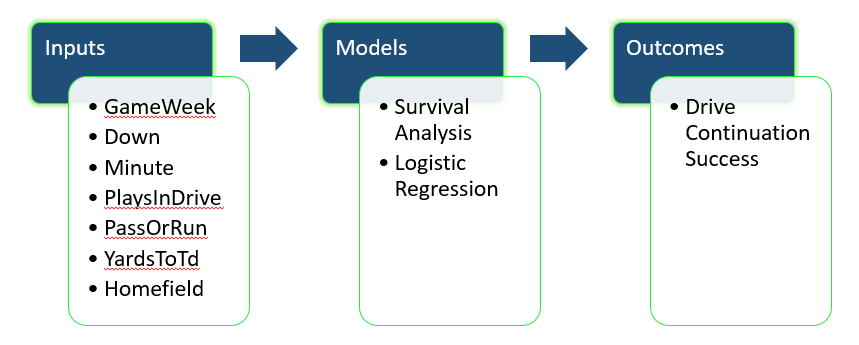

Over all both of the models were chosen because they would provide easy fitting and interpretation with little hyperparameter tuning. My main concern in the process was to provide the Seahawks an easy interpretable and useable program with minimal explanation needed as to what was occurring or for it to fall under a “black-box” category.

## Model Training and Assessment

```
##    Quarter Minute Week Down ToGo PlayNumInDrive OffDriveOver IsOffHomeTeam
## 54       1     14    1    1   10              1            0          Away
## 55       1     14    1    2    4              2            0          Away
## 56       1     14    1    1   10              3            0          Away
##    IsPass
## 54      0
## 55      0
## 56      0
```

For the model process using the package “caTools”, I used the ‘sample.split’ function which allowed me to split the data into a testing and training group under a split-ratio of 80% training and 20% testing. After the split for testing data and training, I fed a subset of the data training into a Cox survival model from the ‘survival’ package and also fed the training set into the binomial generalize linear model function to create weights for the features. The survival model worked under the formula based on the continuation of a drive (OffDriveOver = 0) and how this was affected by the other features. The logistic regression calculated the relation between the feature PlaySuccess and the reminder of the features in the subset.

## Evaluation and Recommendations

For the model evaluation and recommendation, I decided to consider that the model more than likely would no be able to be used in game during a season. Moreover, I considered that Couch Carroll would only consider the recommendation of the model, if it showed over an 80% accuracy in predicting a play, when given over 80% in the probability of a play succeeding. I was then able to prove to coach that the model could perform under these requirements as shown in figure 3 and figure 4, between the 85% to 93% threshold of confidence. Even after being run through and checked for adjustment through the ROC curve and confusion matrix, the logistic regression model was already performing at its best outcome, seen below.

```
##            PredictedValue
## ActualValue FALSE  TRUE
##           0  6709 11769
##           1   646 22902
```

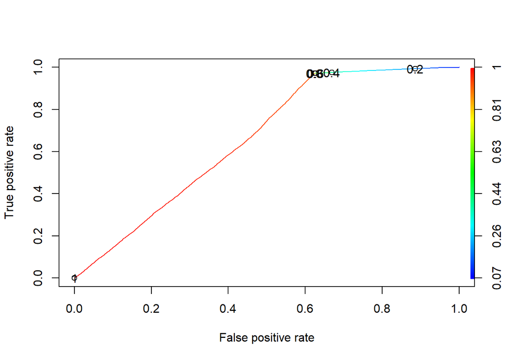

```
##      [,1]                                  [,2]
## [1,] "Survival Model Accuracy at 80% : "   "0.889593453135843"
## [2,] "Regression Model Accuracy at 80% : " "0.867292000670001"
```

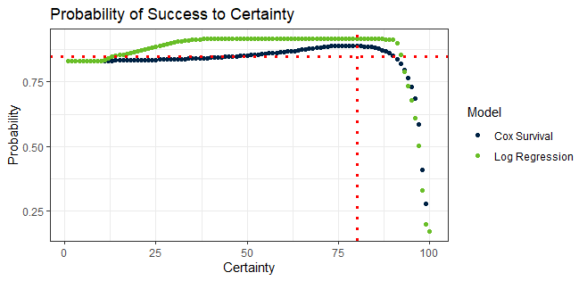

## Data and Code

The following R files can be run in order to obtain, clean, prepare data and then train the models.

- 001-data-preparation.R
- 002-model-preparation.R